# Bellabeat Capstone Project

Kim Donaldson

8/26/2021

## Google Data Analytics Professional Certificate Capstone Project

Hi, my name is Kim Donaldson. Thanks for reviewing my capstone project for the Google Data Analytics Professional Certificate. I’m excited to put what I’ve learned to good use. I chose the bellabeat case study because I have an interest in fitness. As I have been going through the coursework on coursera I have not been excercising as much. So, I hope to not only find interesting insights that could be applied to business products, but also some inspiration to get active.

## About Bellabeat

Bellabeat is a manufacturer of smart devices for women. Bellabeats mission is to empower women with data to discover themselves. Key Stakeholers include:

- Urška Sršen - Cofounder, Chief Creative Officer
- Sando Mur - Mathmematician and cofounder
- Marketing Analytics Team

## Scope of work

Analyze fitbit data to gain insights into how smart devices are used and provide key insights to help the marketing team make data driven decisions.

1. Identify trends in smart device usage
2. Determine how relevant these trends are for Bellabeat customers
3. Determine how these trends can help guide the Marketing Analytics Team

## The Products

- Bellabeat App - Provides users with data related to activity, sleep, stress, menstrual cycle, and mindfulness habits.
- Ivy - A health tracker designed to be worn as a bracelet. Measures Steps, active time, calories, distance, active heart rate, and workout intensity, sleep duration, sleep quality, resting heart rate, respitatory rate, and cardiac coherence.
- Leaf Urban - An elegant health tracker that can be worn as a bracelet, necklace, or clip. Records data to track activity, sleep, stress, and reproductive health.
- Time - Luxury hybrid wellness watch that track activity, sleep, and stress. Offered in Silver and Rose Gold
- Spring - Waterbottle that tracks water intake, connects with Bellabeat App
- Bellabeat Membership - Subscription based program that provides guidance on nutrition activity, sleep, health, beauty, and mindufulness with a focus on lifestyle and goals.
- Accessories - Includes bracelets, neclaces, water bottles, and yoga mats.

## Business Purpose

This case study will focus on finding insights that could grow the number of customers that purchase the Bellabeat+ Club subscription. My hypothesis is that more active people are more likely to purchase the exclusive subscription services. Therefore highly active people can be grouped into two categories: members that are currenst subscribers, and members that are not subscribed.

### Import Packages

```r
library(tidyverse)
library(lubridate)
```

### Import the datasets

```r
daily_activity <- read_csv("fitbit/Fitabase_Data_4.12.16-5.12.16/dailyActivity_merged.csv")
sleep_day <- read_csv("fitbit/Fitabase_Data_4.12.16-5.12.16/sleepDay_merged.csv")
```

Inspecting the datasets

```r
colnames(daily_activity)
```

```
##  [1] "Id"                       "ActivityDate"
##  [3] "TotalSteps"               "TotalDistance"
##  [5] "TrackerDistance"          "LoggedActivitiesDistance"
##  [7] "VeryActiveDistance"       "ModeratelyActiveDistance"
##  [9] "LightActiveDistance"      "SedentaryActiveDistance"
## [11] "VeryActiveMinutes"        "FairlyActiveMinutes"
## [13] "LightlyActiveMinutes"     "SedentaryMinutes"
## [15] "Calories"
```

```r
colnames(sleep_day)
```

```
## [1] "Id"                 "SleepDay"           "TotalSleepRecords"
## [4] "TotalMinutesAsleep" "TotalTimeInBed"
```

Looking at TotalDistance and TrackerDistance we can see that most of these values are the same. Tracker Distance should never be greater than TotalDistance. We can look at how many times they contain unique values and check to see if there any errors in the reporting.

```r
case_a <- daily_activity %>%
  filter(TrackerDistance != TotalDistance)
case_b <- daily_activity %>%
  filter(TrackerDistance > TotalDistance)
```

Case A contains 15 obs. This shows that 1.6 percent of the time the total distance isn’t completely tracked. Case B contains 0 obs as expected. I’m assuming that distance is measured in miles and not kilometers. TotalDistance can be broken down into 4 categories: Very Active, Moderately Active, Lightly Active, and Sedentary Active representing the corresponding intensity levels. When we sort by TotalDistance in Desc order we can see that at least one person tracked an ultra distance of 28.03

```r
top_distance <- daily_activity %>%
  arrange(-TotalDistance)
head(top_distance)
```

```
## # A tibble: 6 × 15
##           Id ActivityDate TotalSteps TotalDistance TrackerDistance LoggedActivitie…
##        <dbl> <chr>             <dbl>         <dbl>           <dbl>            <dbl>
## 1 1624580081 5/1/2016          36019          28.0            28.0                0
## 2 8877689391 4/30/2016         27745          26.7            26.7                0
## 3 8877689391 4/16/2016         29326          25.3            25.3                0
## 4 8877689391 4/27/2016         23629          20.6            20.6                0
## 5 8877689391 4/12/2016         23186          20.4            20.4                0
## 6 8877689391 5/11/2016         21420          19.6            19.6                0
## # … with 9 more variables: VeryActiveDistance <dbl>,
## #   ModeratelyActiveDistance <dbl>, LightActiveDistance <dbl>,
## #   SedentaryActiveDistance <dbl>, VeryActiveMinutes <dbl>,
## #   FairlyActiveMinutes <dbl>, LightlyActiveMinutes <dbl>,
## #   SedentaryMinutes <dbl>, Calories <dbl>
```

Organize by grouping by Id, and sort by active minutes. Clean by selecting only the columns that seem interesting for analysis and transform the date to a standard form.

```r
clean_daily_activity <- daily_activity %>% group_by(Id) %>%
  arrange(-VeryActiveMinutes, -FairlyActiveMinutes, -LightlyActiveMinutes) %>%
  select(Id, ActivityDate, TotalSteps, TotalDistance, VeryActiveMinutes, FairlyActiveMinutes, LightlyActiveMinutes, Calories)

clean_daily_activity <- daily_activity %>% mutate(
  Date = as.Date(mdy(ActivityDate))) %>% select(-ActivityDate)

num_members <- n_distinct(clean_daily_activity$Id) # 33 particiapnts

clean_daily_activity %>% select(-Id, -Date) %>% summary()
```

```
##    TotalSteps    TotalDistance    TrackerDistance  LoggedActivitiesDistance
##  Min.   :    0   Min.   : 0.000   Min.   : 0.000   Min.   :0.0000
##  1st Qu.: 3790   1st Qu.: 2.620   1st Qu.: 2.620   1st Qu.:0.0000
##  Median : 7406   Median : 5.245   Median : 5.245   Median :0.0000
##  Mean   : 7638   Mean   : 5.490   Mean   : 5.475   Mean   :0.1082
##  3rd Qu.:10727   3rd Qu.: 7.713   3rd Qu.: 7.710   3rd Qu.:0.0000
##  Max.   :36019   Max.   :28.030   Max.   :28.030   Max.   :4.9421
##  VeryActiveDistance ModeratelyActiveDistance LightActiveDistance
##  Min.   : 0.000     Min.   :0.0000           Min.   : 0.000
##  1st Qu.: 0.000     1st Qu.:0.0000           1st Qu.: 1.945
##  Median : 0.210     Median :0.2400           Median : 3.365
##  Mean   : 1.503     Mean   :0.5675           Mean   : 3.341
##  3rd Qu.: 2.053     3rd Qu.:0.8000           3rd Qu.: 4.782
##  Max.   :21.920     Max.   :6.4800           Max.   :10.710
##  SedentaryActiveDistance VeryActiveMinutes FairlyActiveMinutes
##  Min.   :0.000000        Min.   :  0.00    Min.   :  0.00
##  1st Qu.:0.000000        1st Qu.:  0.00    1st Qu.:  0.00
##  Median :0.000000        Median :  4.00    Median :  6.00
##  Mean   :0.001606        Mean   : 21.16    Mean   : 13.56
##  3rd Qu.:0.000000        3rd Qu.: 32.00    3rd Qu.: 19.00
##  Max.   :0.110000        Max.   :210.00    Max.   :143.00
##  LightlyActiveMinutes SedentaryMinutes    Calories
##  Min.   :  0.0        Min.   :   0.0   Min.   :   0
##  1st Qu.:127.0        1st Qu.: 729.8   1st Qu.:1828
##  Median :199.0        Median :1057.5   Median :2134
##  Mean   :192.8        Mean   : 991.2   Mean   :2304
##  3rd Qu.:264.0        3rd Qu.:1229.5   3rd Qu.:2793
##  Max.   :518.0        Max.   :1440.0   Max.   :4900
```

This shows that Lightly Active Minutes are the most common. Let’s look closer at relationship between activity intensities minutes.

```r
active_intensities_t <- clean_daily_activity %>% group_by(Id) %>%
  summarize(avg_very_active_t = mean(VeryActiveMinutes),
            avg_fair_active_t = mean(FairlyActiveMinutes),
            avg_light_active_t = mean(LightlyActiveMinutes),
            avg_sed_active_t = mean(SedentaryMinutes)
            ) %>%
  arrange(-avg_very_active_t)

head(active_intensities_t)
```

```
## # A tibble: 6 × 5
##           Id avg_very_active… avg_fair_active… avg_light_activ… avg_sed_active_t
##        <dbl>            <dbl>            <dbl>            <dbl>            <dbl>
## 1 5577150313             87.3            29.8              148.             754.
## 2 8053475328             85.2             9.58             151.            1148
## 3 8877689391             66.1             9.94             235.            1113.
## 4 8378563200             58.7            10.3              156.             716.
## 5 7086361926             42.6            25.4              144.             850.
## 6 1503960366             38.7            19.2              220.             848.
```

This shows us a list of particpants who spend the highest amount of time on average being Very Active.

### Sleep Data

- Remove the timestamp and rename the column.
- Create a new column with proportion of sleep time.

```r
clean_sleep_day <- sleep_day %>% mutate(Date = as.Date(mdy_hms(SleepDay))) %>%
  select(-SleepDay, -TotalSleepRecords)

clean_sleep_day <- clean_sleep_day %>% mutate(PropSleep = TotalMinutesAsleep / TotalTimeInBed) %>%
  select(Id, Date, PropSleep)
```

I want to see if there is a positive correlation between step count and sleep quality.

```r
step_sleep <- merge(clean_daily_activity, clean_sleep_day, by = c("Id", "Date"))
step_sleep <- step_sleep %>% select(TotalSteps, TotalDistance, PropSleep)
```

### Visualize

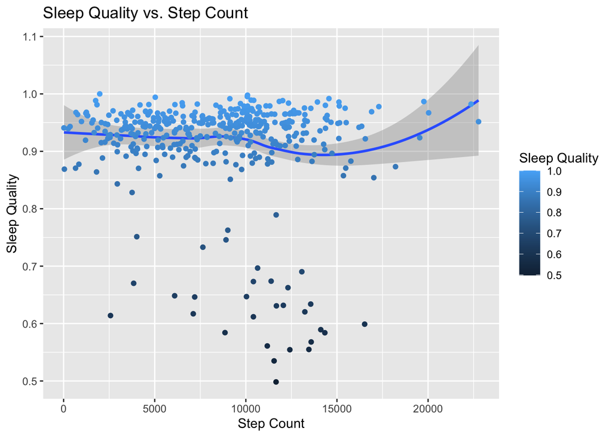

```r
ggplot(data = step_sleep) +
  aes(x = TotalSteps, y = PropSleep, color = PropSleep) +
  geom_smooth() +
  geom_point() +
  labs(title = "Sleep Quality vs. Step Count", x = "Step Count", y = "Sleep Quality",
       color = "Sleep Quality")
```

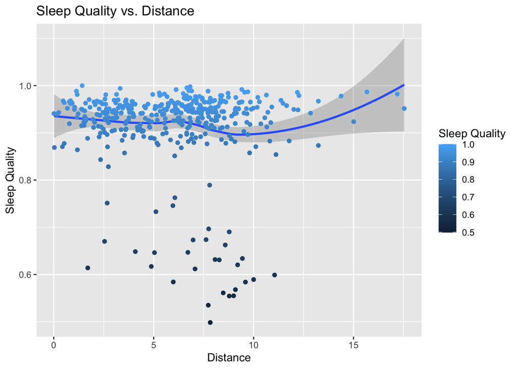

```r
ggplot(data = step_sleep) +
  aes(x = TotalDistance, y = PropSleep, color = PropSleep) +
  geom_smooth() +
  geom_point() +
  #theme(legend.title = "Sleep Quality") +
  labs(title = "Sleep Quality vs. Distance", x = "Distance", y = "Sleep Quality",
       color = "Sleep Quality")
```

Since the fitbit data does not contain information about gender let’s look at some external datasets to examine womens level of participation in the Boston Marathons.

```r
boston_results_2015 <- read_csv("boston/marathon_results_2015.csv")
```

```
## * `` -> ...1
## * `` -> ...10
```

```r
boston_results_2016 <- read_csv("boston/marathon_results_2016.csv")
```

```
## * `` -> ...9
```

```r
boston_results_2017 <- read_csv("boston/marathon_results_2017.csv")
```

```
## * `` -> ...1
## * `` -> ...10
```

```r
clean_br_2015 <- boston_results_2015 %>% select(MF) %>% mutate(Year = "2015")
clean_br_2016 <- boston_results_2016 %>% select(MF) %>% mutate(Year = "2016")
clean_br_2017 <- boston_results_2017 %>% select(MF) %>% mutate(Year = "2017")

boston_results <- rbind(clean_br_2015, clean_br_2016, clean_br_2017)
```

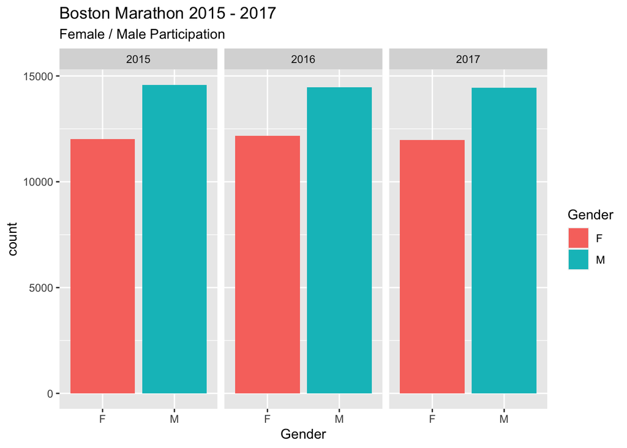

```r
ggplot(boston_results) +
  aes(x = MF, fill = MF) +
  geom_bar() +
  labs(title = "Boston Marathon 2015 - 2017", subtitle = "Female / Male Participation", x = "Gender", fill = "Gender") +
  facet_wrap(~Year)
```